# Multivariate normal scenarios of real returns

```julia
# Defaults for running the cells outside Quarto. Under `quarto render` the front-matter
# `params` (overridden by `-P name:value` or `--execute-params file.yml`, see
# render_mvn_reports.sh) are already defined as constants, so these assignments are skipped.
@isdefined(params_file) || (params_file = "specs/mvn/cma_hist1935-2025.yaml")
@isdefined(T) || (T = 100)                      # simulated years
@isdefined(horizons) || (horizons = [1, 5, 10, 20, 30, 50, 100])  # horizon table years, ≤ T
@isdefined(n_scen) || (n_scen = 10000)
@isdefined(seed) || (seed = 1234)
```

```julia
import Pkg
Pkg.activate(joinpath(@__DIR__, "..", ".."); io = devnull)

using MacroFinanceScenarios
using MacroFinanceScenarios.IbbotsonSinquefield
using MacroFinanceScenarios.EDA
using MacroFinanceScenarios.ScenariosEvaluation
using CSV, DataFrames, Random, Statistics, TimeSeries
using Plots

show_table(t; title = "", digits = 2) =
    display(HTML(sprint(io -> print_table(io, t; backend = :html, digits, title))))

# Everything loaded and computed is in decimal log units; the report shows percent. Means,
# std and percentiles scale by 100; skewness, kurtosis, autocorrelations and correlations
# do not, and `neg` (share of negative values) is already in percent.
pct(sc::Scenarios) = Scenarios(100 .* sc.data, sc.names, sc.start_year)
function pct(df::DataFrame; cols)
    out = copy(df)
    for c in cols
        out[!, c] = 100 .* out[!, c]
    end
    return out
end
moment_cols = [:mean, :std, :min, :p25, :p50, :p75, :max]   # describe_series columns in %
span(p) = "$(p[1])–$(p[2])"

p = load_mvn_params(joinpath(@__DIR__, params_file))
vars = p.names
```

## Distribution and assumptions

Each simulated year is an independent draw of the annual log real returns — the real T-bill return `r`, the real bond return `rb_real` and the real equity return `re_real` — from a multivariate normal distribution `N(μ, Σ)`, with `Σ = diag(σ) · C · diag(σ)`. The parameters are read from specs/mvn/cma_hist1935-2025.yaml. The means are means of annual **log** returns: a simple expected return `E[R]` corresponds to roughly `log(1 + E[R]) − σ²/2`.

```julia
show_table(DataFrame(variable = String.(vars), mean = 100p.μ, std = 100p.σ,
                     simple_mean = 100(exp.(p.μ .+ p.σ .^ 2 ./ 2) .- 1));
           title = "Annual log real returns (%); simple_mean = E[exp(x)] − 1")
show_table(DataFrame(p.C, String.(vars)) |> t -> insertcols!(t, 1, :variable => String.(vars));
           title = "Correlation")
show_table(DataFrame(parameter = ["params file", "first simulated year", "simulated years",
                                  "scenarios", "seed"],
                     value = [params_file, string(p.start_year), string(T), string(n_scen),
                              string(seed)]);
           title = "Parameters")
```

| Annual log real returns (%); simple_mean = E[exp(x)] − 1 variable String | Annual log real returns (%); simple_mean = E[exp(x)] − 1 mean Float64 | Annual log real returns (%); simple_mean = E[exp(x)] − 1 std Float64 | Annual log real returns (%); simple_mean = E[exp(x)] − 1 simple_mean Float64 |
| --- | --- | --- | --- |
| r | 0.5 | 3.46 | 0.56 |
| rb_real | 1.5 | 8.03 | 1.84 |
| re_real | 5.5 | 17.29 | 7.25 |

| Correlation variable String | Correlation r Float64 | Correlation rb_real Float64 | Correlation re_real Float64 |
| --- | --- | --- | --- |
| r | 1.0 | 0.64 | 0.28 |
| rb_real | 0.64 | 1.0 | 0.18 |
| re_real | 0.28 | 0.18 | 1.0 |

| Parameters parameter String | Parameters value String |
| --- | --- |
| params file | specs/mvn/cma_hist1935-2025.yaml |
| first simulated year | 2026 |
| simulated years | 100 |
| scenarios | 10000 |
| seed | 1234 |

Units: returns and moments below are annual log values in percent, except where a table or chart says *simple rate* (`exp(·) − 1` of the log rate, in percent) or *wealth* (of 1 invested); skewness, excess kurtosis, autocorrelations and correlations are unit-free.

## Historical moments

```julia
has_hist = p.hist_period !== nothing
has_hist || println("The params file has no `hist_period`; historical comparisons are skipped.")
```

```
true
```

```julia
if has_hist
    raw = TimeArray(CSV.File(joinpath(@__DIR__, "..", "..", "data", "shiller_annual.csv"));
                    timestamp = :timestamp)
    data = subperiod(raw[vars...], p.hist_period)
    hist_moments = describe_series(data)
    hist_cor = correlation_table(data)
    hist_pct = pct(hist_moments; cols = moment_cols)
    show_table(hist_pct; title = "Historical sample, $(span(p.hist_period)) (not mean-adjusted)")
    show_table(hist_cor; title = "Correlations, $(span(p.hist_period))")
else
    hist_pct = hist_cor = nothing
end
```

| Historical sample, 1935–2025 (not mean-adjusted) variable String | Historical sample, 1935–2025 (not mean-adjusted) mean Float64 | Historical sample, 1935–2025 (not mean-adjusted) std Float64 | Historical sample, 1935–2025 (not mean-adjusted) skewness Float64 | Historical sample, 1935–2025 (not mean-adjusted) ex_kurtosis Float64 | Historical sample, 1935–2025 (not mean-adjusted) ar1 Float64 | Historical sample, 1935–2025 (not mean-adjusted) neg Float64 | Historical sample, 1935–2025 (not mean-adjusted) min Float64 | Historical sample, 1935–2025 (not mean-adjusted) p5 Float64 | Historical sample, 1935–2025 (not mean-adjusted) p25 Float64 | Historical sample, 1935–2025 (not mean-adjusted) p50 Float64 | Historical sample, 1935–2025 (not mean-adjusted) p75 Float64 | Historical sample, 1935–2025 (not mean-adjusted) p95 Float64 | Historical sample, 1935–2025 (not mean-adjusted) max Float64 |
| --- | --- | --- | --- | --- | --- | --- | --- | --- | --- | --- | --- | --- | --- |
| r | -0.14 | 3.46 | -1.5 | 4.56 | 0.55 | 41.76 | -16.28 | -0.06 | -1.77 | 0.46 | 1.74 | 0.04 | 6.54 |
| rb_real | 1.0 | 8.03 | 0.11 | 0.56 | 0.1 | 42.86 | -22.41 | -0.11 | -3.68 | 0.96 | 5.25 | 0.14 | 23.94 |
| re_real | 7.06 | 17.29 | -0.96 | 0.83 | -0.02 | 28.57 | -49.11 | -0.25 | -2.04 | 11.45 | 18.0 | 0.29 | 39.12 |

| Correlations, 1935–2025 variable String | Correlations, 1935–2025 r Float64 | Correlations, 1935–2025 rb_real Float64 | Correlations, 1935–2025 re_real Float64 |
| --- | --- | --- | --- |
| r | 1.0 | 0.64 | 0.28 |
| rb_real | 0.64 | 1.0 | 0.18 |
| re_real | 0.28 | 0.18 | 1.0 |

Under the normal i.i.d. model skewness, excess kurtosis and autocorrelations are 0; the historical values show what the model leaves out.

## Simulation

No moment matching is applied after the simulation: the gap between the achieved mean and the distribution mean is sampling noise, summarised by its standard error (std of the per-path means / √n_scen).

```julia
sc = simulate_mvn(p, T, n_scen; rng = MersenneTwister(seed))
path_means = dropdims(mean(sc.data; dims = 2); dims = 2)   # n_vars × n_scen
achieved = DataFrame(variable = String.(sc.names),
                     target = 100p.μ,
                     simulated = 100vec(mean(path_means; dims = 2)),
                     se = 100vec(std(path_means; dims = 2)) ./ sqrt(n_scen))
achieved.z = (achieved.simulated .- achieved.target) ./ achieved.se
show_table(achieved; title = "Mean over all years and paths vs. target (%)")
println("Simulated years $(first(scenario_years(sc)))–$(last(scenario_years(sc))).")
```

```
Simulated years 2026–2125.
```

| Mean over all years and paths vs. target (%) variable String | Mean over all years and paths vs. target (%) target Float64 | Mean over all years and paths vs. target (%) simulated Float64 | Mean over all years and paths vs. target (%) se Float64 | Mean over all years and paths vs. target (%) z Float64 |
| --- | --- | --- | --- | --- |
| r | 0.5 | 0.5 | 0.0 | -0.43 |
| rb_real | 1.5 | 1.5 | 0.01 | -0.01 |
| re_real | 5.5 | 5.5 | 0.02 | -0.02 |

## Fan charts

5–95 and 25–75 percentile bands, median, and the distribution mean (dashed).

```julia
μ_target = Dict(zip(vars, p.μ))
fans(vars; kwargs...) = [fan(sc, v; μ = μ_target[v], μ_label = "mean", kwargs...) for v in vars]
```

```
fans (generic function with 1 method)
```

### Cumulative wealth

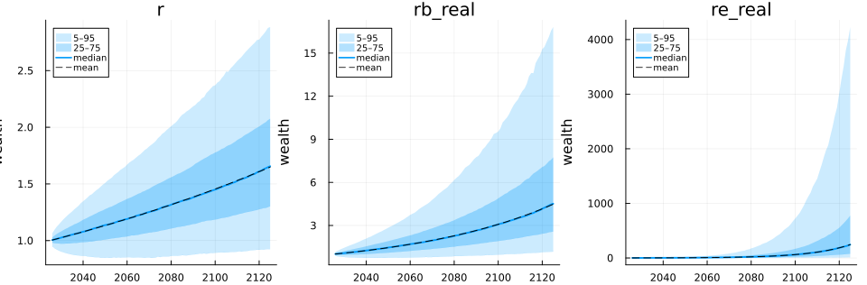

Wealth of 1 invested, real

```julia
plot(fans(vars; kind = :wealth)...; layout = (1, length(vars)), size = (1000, 330), ylabel = "wealth")
```

### Annualised returns

Geometric-average annual return over the first `h` years, `exp(sum(x_1..h)/h) − 1`.

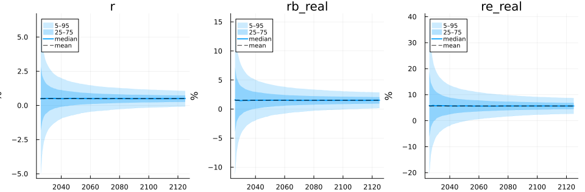

Annualised simple real rates

```julia
plot(fans(vars; kind = :annualised, simple = true, scale = 100)...;
     layout = (1, length(vars)), size = (1000, 330), ylabel = "%")
```

## Evaluation

### Per-path moments

Statistics computed within each simulated path, then summarised across scenarios; the `historical` column is the historical sample (if `hist_period` is set). `neg` is the percent of years with a negative value.

```julia
for (name, t) in path_moments(pct(sc); hist = hist_pct)
    show_table(t; title = String(name))
end
```

| r statistic String | r historical Float64 | r mean Float64 | r p5 Float64 | r p25 Float64 | r p50 Float64 | r p75 Float64 | r p95 Float64 |
| --- | --- | --- | --- | --- | --- | --- | --- |
| mean | -0.14 | 0.5 | -0.08 | 0.26 | 0.5 | 0.73 | 1.06 |
| std | 3.46 | 3.45 | 3.06 | 3.29 | 3.45 | 3.61 | 3.85 |
| skewness | -1.5 | 0.0 | -0.39 | -0.16 | -0.0 | 0.16 | 0.39 |
| ex_kurtosis | 4.56 | -0.06 | -0.65 | -0.37 | -0.13 | 0.17 | 0.76 |
| ar1 | 0.55 | -0.01 | -0.17 | -0.08 | -0.01 | 0.06 | 0.15 |
| neg | 41.76 | 44.3 | 36.0 | 41.0 | 44.0 | 48.0 | 52.0 |

| rb_real statistic String | rb_real historical Float64 | rb_real mean Float64 | rb_real p5 Float64 | rb_real p25 Float64 | rb_real p50 Float64 | rb_real p75 Float64 | rb_real p95 Float64 |
| --- | --- | --- | --- | --- | --- | --- | --- |
| mean | 1.0 | 1.5 | 0.17 | 0.95 | 1.51 | 2.05 | 2.82 |
| std | 8.03 | 7.99 | 7.09 | 7.61 | 7.98 | 8.37 | 8.94 |
| skewness | 0.11 | -0.0 | -0.39 | -0.16 | -0.0 | 0.15 | 0.38 |
| ex_kurtosis | 0.56 | -0.06 | -0.65 | -0.37 | -0.13 | 0.17 | 0.76 |
| ar1 | 0.1 | -0.01 | -0.17 | -0.08 | -0.01 | 0.06 | 0.15 |
| neg | 42.86 | 42.58 | 34.0 | 39.0 | 43.0 | 46.0 | 51.0 |

| re_real statistic String | re_real historical Float64 | re_real mean Float64 | re_real p5 Float64 | re_real p25 Float64 | re_real p50 Float64 | re_real p75 Float64 | re_real p95 Float64 |
| --- | --- | --- | --- | --- | --- | --- | --- |
| mean | 7.06 | 5.5 | 2.66 | 4.36 | 5.5 | 6.66 | 8.35 |
| std | 17.29 | 17.25 | 15.26 | 16.41 | 17.24 | 18.06 | 19.32 |
| skewness | -0.96 | 0.0 | -0.39 | -0.16 | 0.0 | 0.16 | 0.4 |
| ex_kurtosis | 0.83 | -0.06 | -0.65 | -0.37 | -0.13 | 0.18 | 0.77 |
| ar1 | -0.02 | -0.01 | -0.17 | -0.08 | -0.01 | 0.06 | 0.15 |
| neg | 28.57 | 37.52 | 30.0 | 34.0 | 37.0 | 41.0 | 45.0 |

### Correlations

Correlations computed within each simulated path, then summarised across scenarios. The matrix is the mean across paths. In the pair table, `historical` is the correlation in the sample and `hist_rank` the share of paths with a correlation at or below it. Each path covers 100 years, so the bands show what a 100-year window looks like.

```julia
show_table(mean_path_correlations(sc); title = "Mean within-path correlations")
show_table(path_correlations(sc; hist = hist_cor); title = "Pairs")
```

| Mean within-path correlations variable String | Mean within-path correlations r Float64 | Mean within-path correlations rb_real Float64 | Mean within-path correlations re_real Float64 |
| --- | --- | --- | --- |
| r | 1.0 | 0.64 | 0.28 |
| rb_real | 0.64 | 1.0 | 0.18 |
| re_real | 0.28 | 0.18 | 1.0 |

| Pairs var1 String | Pairs var2 String | Pairs historical Float64 | Pairs mean Float64 | Pairs p5 Float64 | Pairs p25 Float64 | Pairs p50 Float64 | Pairs p75 Float64 | Pairs p95 Float64 | Pairs hist_rank Float64 |
| --- | --- | --- | --- | --- | --- | --- | --- | --- | --- |
| r | rb_real | 0.64 | 0.64 | 0.54 | 0.6 | 0.64 | 0.68 | 0.73 | 0.49 |
| r | re_real | 0.28 | 0.28 | 0.13 | 0.22 | 0.28 | 0.35 | 0.43 | 0.5 |
| rb_real | re_real | 0.18 | 0.18 | 0.02 | 0.12 | 0.19 | 0.25 | 0.34 | 0.49 |

### Horizon percentiles

Annualised returns: the geometric-average annual return over `h` years, `exp(sum(x_1..h)/h) − 1`, in percent.

```julia
function horizon_tables(vars; kind, label)
    for v in vars
        t = select(horizon_percentiles(sc; vars = [v], horizons = filter(<=(T), horizons), kind,
                                       probs = [0.0, 0.05, 0.25, 0.5, 0.75, 0.95, 1.0],
                                       simple = true), Not(:variable))
        t = DataFrames.rename(t, :p0 => :min, :p100 => :max)
        t = pct(t; cols = names(t, Not([:horizon, :year])))
        show_table(t; title = "$v, $label")
    end
end
horizon_tables(vars; kind = :annualised, label = "annualised (simple rate, %)")
```

| r, annualised (simple rate, %) horizon Int64 | r, annualised (simple rate, %) year Int64 | r, annualised (simple rate, %) mean Float64 | r, annualised (simple rate, %) min Float64 | r, annualised (simple rate, %) p5 Float64 | r, annualised (simple rate, %) p25 Float64 | r, annualised (simple rate, %) p50 Float64 | r, annualised (simple rate, %) p75 Float64 | r, annualised (simple rate, %) p95 Float64 | r, annualised (simple rate, %) max Float64 |
| --- | --- | --- | --- | --- | --- | --- | --- | --- | --- |
| 1.0 | 2026.0 | 0.55 | -11.46 | -5.0 | -1.81 | 0.49 | 2.85 | 6.38 | 14.56 |
| 5.0 | 2030.0 | 0.51 | -6.76 | -2.0 | -0.56 | 0.5 | 1.56 | 3.1 | 6.08 |
| 10.0 | 2035.0 | 0.51 | -3.39 | -1.3 | -0.23 | 0.51 | 1.25 | 2.31 | 4.82 |
| 20.0 | 2045.0 | 0.51 | -2.19 | -0.78 | -0.02 | 0.51 | 1.05 | 1.8 | 3.52 |
| 30.0 | 2055.0 | 0.51 | -2.29 | -0.55 | 0.08 | 0.5 | 0.93 | 1.56 | 3.18 |
| 50.0 | 2075.0 | 0.5 | -1.52 | -0.31 | 0.17 | 0.5 | 0.83 | 1.31 | 2.34 |

| rb_real, annualised (simple rate, %) horizon Int64 | rb_real, annualised (simple rate, %) year Int64 | rb_real, annualised (simple rate, %) mean Float64 | rb_real, annualised (simple rate, %) min Float64 | rb_real, annualised (simple rate, %) p5 Float64 | rb_real, annualised (simple rate, %) p25 Float64 | rb_real, annualised (simple rate, %) p50 Float64 | rb_real, annualised (simple rate, %) p75 Float64 | rb_real, annualised (simple rate, %) p95 Float64 | rb_real, annualised (simple rate, %) max Float64 |
| --- | --- | --- | --- | --- | --- | --- | --- | --- | --- |
| 1.0 | 2026.0 | 1.84 | -24.8 | -11.13 | -3.84 | 1.59 | 7.21 | 15.64 | 35.8 |
| 5.0 | 2030.0 | 1.54 | -12.37 | -4.26 | -1.0 | 1.45 | 3.96 | 7.67 | 15.11 |
| 10.0 | 2035.0 | 1.52 | -8.33 | -2.63 | -0.24 | 1.47 | 3.26 | 5.77 | 11.41 |
| 20.0 | 2045.0 | 1.53 | -5.83 | -1.48 | 0.27 | 1.53 | 2.78 | 4.59 | 11.06 |
| 30.0 | 2055.0 | 1.53 | -4.73 | -0.92 | 0.52 | 1.53 | 2.52 | 4.0 | 8.46 |
| 50.0 | 2075.0 | 1.52 | -3.74 | -0.37 | 0.74 | 1.5 | 2.27 | 3.45 | 6.66 |

| re_real, annualised (simple rate, %) horizon Int64 | re_real, annualised (simple rate, %) year Int64 | re_real, annualised (simple rate, %) mean Float64 | re_real, annualised (simple rate, %) min Float64 | re_real, annualised (simple rate, %) p5 Float64 | re_real, annualised (simple rate, %) p25 Float64 | re_real, annualised (simple rate, %) p50 Float64 | re_real, annualised (simple rate, %) p75 Float64 | re_real, annualised (simple rate, %) p95 Float64 | re_real, annualised (simple rate, %) max Float64 |
| --- | --- | --- | --- | --- | --- | --- | --- | --- | --- |
| 1.0 | 2026.0 | 7.18 | -41.09 | -20.43 | -6.04 | 5.8 | 18.83 | 39.43 | 104.82 |
| 5.0 | 2030.0 | 6.03 | -19.74 | -6.82 | 0.25 | 5.7 | 11.52 | 19.93 | 40.83 |
| 10.0 | 2035.0 | 5.86 | -14.37 | -3.46 | 1.91 | 5.75 | 9.68 | 15.59 | 31.59 |
| 20.0 | 2045.0 | 5.72 | -10.01 | -0.86 | 2.95 | 5.62 | 8.43 | 12.66 | 22.09 |
| 30.0 | 2055.0 | 5.73 | -5.48 | 0.32 | 3.42 | 5.65 | 7.94 | 11.41 | 18.6 |
| 50.0 | 2075.0 | 5.69 | -3.51 | 1.43 | 3.94 | 5.65 | 7.4 | 10.05 | 16.29 |

### Drawdowns

Maximum drawdown of wealth (in %) and the longest spell below a previous peak (in years), per path over the first `horizon` simulated years (50 by default, at most `T`).

```julia
function dd_table(s; horizon = 50)
    horizon <= size(s.data, 2) || throw(ArgumentError("horizon $horizon exceeds the $(size(s.data, 2)) simulated years"))
    t = drawdown_table(Scenarios(s.data[:, 1:horizon, :], s.names, s.start_year))
    rows = t.statistic .== "max_drawdown"
    num = names(t, Not([:variable, :statistic]))
    t[rows, num] .*= 100
    return t
end
dd_h = min(50, T)
show_table(dd_table(sc; horizon = dd_h); title = "Real, first $dd_h years")
```

| Real, first 50 years variable String | Real, first 50 years statistic String | Real, first 50 years mean Float64 | Real, first 50 years p5 Float64 | Real, first 50 years p25 Float64 | Real, first 50 years p50 Float64 | Real, first 50 years p75 Float64 | Real, first 50 years p95 Float64 |
| --- | --- | --- | --- | --- | --- | --- | --- |
| r | max_drawdown | 16.74 | 8.04 | 11.7 | 15.37 | 20.51 | 29.88 |
| r | max_dd_length | 21.87 | 7.0 | 13.0 | 19.0 | 29.0 | 46.0 |
| rb_real | max_drawdown | 31.29 | 16.1 | 23.19 | 29.67 | 37.82 | 52.12 |
| rb_real | max_dd_length | 19.16 | 6.0 | 11.0 | 17.0 | 25.0 | 42.0 |
| re_real | max_drawdown | 45.98 | 26.53 | 36.11 | 44.76 | 54.62 | 69.65 |
| re_real | max_dd_length | 13.27 | 5.0 | 8.0 | 11.0 | 17.0 | 29.0 |